# R Notebook

Project Notes

This will be where you can write/add your notes to help keep yourself more organised

Artist quad is done as well as the corrplot, now you might want to compare correlations of other features between artists? What is the best way to store the data from the different artists?

Compare artist ranks on these measures.

Offline_stream_history is where you have the data of your spotify stream history. You did some cleaning to make the DF more useful.

If you want to analyse specifics of the music, use spotifyr Check the differences for

Short

```r
get_my_top_artists_or_tracks(type = tracks, limit = 50,
  time_range = "short_term",
  authorization = get_spotify_authorization_code(),
  include_meta_info = TRUE) #play around with these
```

Medium

```r
get_my_top_artists_or_tracks(type = tracks, limit = 50,
  time_range = "medium_term",
  authorization = get_spotify_authorization_code(),
  include_meta_info = TRUE) #play around with these
```

Long

```r
get_my_top_artists_or_tracks(type = tracks, limit = 50,
  time_range = "long_term",
  authorization = get_spotify_authorization_code(),
  include_meta_info = TRUE) #play around with these
```

get_my_recently_played(limit = 50, authorization = get_spotify_authorization_code(), include_meta_info = TRUE)

get_playlist_audio_features(username, playlist_uris, authorization = get_spotify_access_token())

Artist/Albums

Any artists you want to compare against each other Albums from an artist you want to compare

Compare TGA’s albums Modest Mouse Ryan Adams

mySpotify

| trackName | artistName | playCount | msPlayed | date | seconds | minutes | endTime |
| --- | --- | --- | --- | --- | --- | --- | --- |
| You Have Stolen My Heart | Brian Fallon | 51 | 225280 | 2020-02-06 | 225.280 | 3.754667e+00 | 2020-02-06 22:59:00 |
| 21 Days | Brian Fallon | 47 | 212600 | 2020-02-06 | 212.600 | 3.543333e+00 | 2020-02-06 22:55:00 |
| Hard Feelings | Brian Fallon | 36 | 251773 | 2020-03-27 | 251.773 | 4.196217e+00 | 2020-03-27 21:57:00 |
| I Don't Mind (If I'm With You) | Brian Fallon | 34 | 95364 | 2020-02-24 | 95.364 | 1.589400e+00 | 2020-02-24 23:19:00 |
| Younger Us | Japandroids | 32 | 20170 | 2020-02-09 | 20.170 | 3.361667e-01 | 2020-02-09 04:30:00 |
| Cul-de-sac | The Wonder Years | 31 | 218471 | 2020-02-12 | 218.471 | 3.641183e+00 | 2020-02-12 21:35:00 |
| Fear and Trembling | Gang of Youths | 30 | 19300 | 2020-02-06 | 19.300 | 3.216667e-01 | 2020-02-06 04:32:00 |
| Romeo And Juliet | Dire Straits | 30 | 145510 | 2020-02-10 | 145.510 | 2.425167e+00 | 2020-02-10 08:26:00 |
| What Can I Do If the Fire Goes Out? | Gang of Youths | 30 | 227000 | 2020-03-04 | 227.000 | 3.783333e+00 | 2020-03-04 06:35:00 |
| Horses | Brian Fallon | 29 | 11200 | 2020-03-24 | 11.200 | 1.866667e-01 | 2020-03-24 06:40:00 |

[output cut: 990 more lines]

```r
mySpotifyArtist2 <- mySpotifyArtist %>%
  select(artistName, playCount) %>%
  rename(playCount=n)
```

[output not shown]

```r
mySpotifyArtist10 <- mySpotifyArtist %>%
  select(artistName, playCount) %>%
  rename(n=playCount) %>%
  top_n(10, n) %>%
  arrange(-n)
```

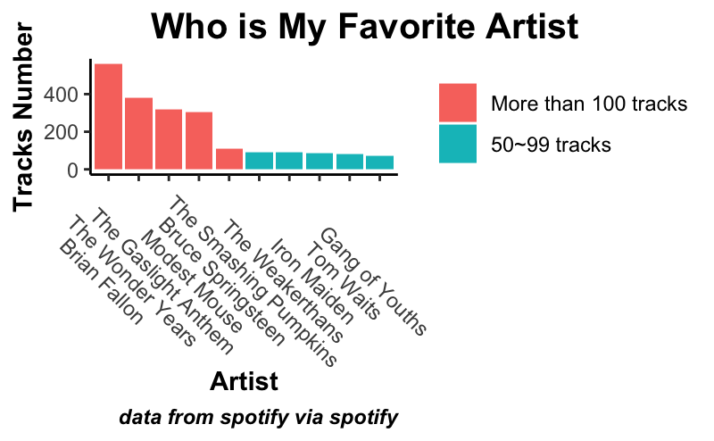

```r
mySpotifyArtist10 %>%
  mutate(
    freq = case_when(
      n > 100 ~ 'More than 100 tracks',
      between(n, 50, 99) ~ '50~99 tracks',
      between(n, 20, 49) ~ '20~49 tracks',
      TRUE ~ 'Less than 20 tracks'
    )
  ) %>%
  mutate(freq = factor(
    freq,
    levels = c(
      'More than 100 tracks',
      '50~99 tracks',
      '20~49 tracks',
      'Less than 20 tracks'
    )
  )) %>%
  ggplot(mapping = aes(
    x = reorder(artistName, -n),
    y = n,
    fill = freq
  )) +
  geom_col() +
  labs(fill = NULL,title = 'Who is My Favorite Artist',caption = 'data from spotify via spotify') +
  xlab('Artist') +
  ylab('Tracks Number') +
  theme_classic() +
  theme(axis.text.x = element_text(angle = -45),
        axis.title = element_text(face = 'bold'),
        plot.title = element_text(hjust = -0.5, face = 'bold', size = 15),
        plot.caption = element_text(hjust = 1,face = 'bold.italic'))
```

```r
NA
NA
```

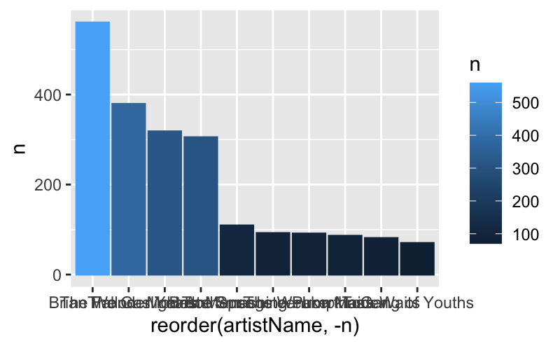

```r
p.color <- ggplot(data = mySpotifyArtist10, mapping = aes(x = reorder(artistName, -n), y = n, color = n))
p.color+geom_col(aes(fill = n) )+ scale_color_gradient()
```

lintr styler